# UCI Heart Disease Classification

Kenneth Lee

12/5/2019

## Introduction

In this project, we aim to train a classifier to accurately classify a person whether or not has a heart disease problem using logistic regression model based on sensitivity and classification accuracy. Also, it will be beneficial to see if we can reduce the number of features to perform a good classification that may potentially lower the costs of collecting expensive features in the future. Most people believe that age should be a strong indicator whether a person has a heart disease problem. Our project will also validate this claim and see if there are any better indicators with hypothesis testing.

```r
# Load packages
library(ROCR)
library(caret)
library(tidyverse)
```

```r
library(ggplot2)

colnames = c("age","sex","chest_pain_type","resting_blood_pressure","serum_cholestoral", "fasting_blood_sugar" ,"resting_results" ,"maximum_heart_rate_achieved","exercise_induced_angina","oldpeak" , "slope", "major_vessels" ,"thal","disease")
data <- read.table("heart.dat", col.names = colnames)
# Dieases: Absence (1) or presence (2) of heart disease
# Sex: 1=male; 0=female

# Check the first few rows of the data
head(data)
```

```
##   age sex chest_pain_type resting_blood_pressure serum_cholestoral
## 1  70   1               4                    130               322
## 2  67   0               3                    115               564
## 3  57   1               2                    124               261
## 4  64   1               4                    128               263
## 5  74   0               2                    120               269
## 6  65   1               4                    120               177
##   fasting_blood_sugar resting_results maximum_heart_rate_achieved
## 1                   0               2                         109
## 2                   0               2                         160
## 3                   0               0                         141
## 4                   0               0                         105
## 5                   0               2                         121
## 6                   0               0                         140
##   exercise_induced_angina oldpeak slope major_vessels thal disease
## 1                       0     2.4     2             3    3       2
## 2                       0     1.6     2             0    7       1
## 3                       0     0.3     1             0    7       2
## 4                       1     0.2     2             1    7       1
## 5                       1     0.2     1             1    3       1
## 6                       0     0.4     1             0    7       1
```

```r
# Check the structure of the data
# Besides disease, all are numeric, 270 rows, 14 columns, 13 features, 1 output. Based on the data description, there is no missing data
str(data)
```

```
## 'data.frame':    270 obs. of  14 variables:
##  $ age                        : num  70 67 57 64 74 65 56 59 60 63 ...
##  $ sex                        : num  1 0 1 1 0 1 1 1 1 0 ...
##  $ chest_pain_type            : num  4 3 2 4 2 4 3 4 4 4 ...
##  $ resting_blood_pressure     : num  130 115 124 128 120 120 130 110 140 150 ...
##  $ serum_cholestoral          : num  322 564 261 263 269 177 256 239 293 407 ...
##  $ fasting_blood_sugar        : num  0 0 0 0 0 0 1 0 0 0 ...
##  $ resting_results            : num  2 2 0 0 2 0 2 2 2 2 ...
##  $ maximum_heart_rate_achieved: num  109 160 141 105 121 140 142 142 170 154 ...
##  $ exercise_induced_angina    : num  0 0 0 1 1 0 1 1 0 0 ...
##  $ oldpeak                    : num  2.4 1.6 0.3 0.2 0.2 0.4 0.6 1.2 1.2 4 ...
##  $ slope                      : num  2 2 1 2 1 1 2 2 2 2 ...
##  $ major_vessels              : num  3 0 0 1 1 0 1 1 2 3 ...
##  $ thal                       : num  3 7 7 7 3 7 6 7 7 7 ...
##  $ disease                    : int  2 1 2 1 1 1 2 2 2 2 ...
```

```r
# Change the sex to be character type
data$sex <- as.character(data$sex)
data$sex <- ifelse(data$sex=="0",'Female','Male')
data$chest_pain_type <- as.factor(data$chest_pain_type)
data$resting_results <- as.factor(data$resting_results)
data$thal <- as.factor(data$thal)
# Change the response variable from 1 and 2 to 0 to 1
data$disease <- ifelse(data$disease==1,0,1)
```

## Data Exploration

We first start off by looking at the distribution of the data. We see that the number of people with heart disease is roughly the same as the number of people who don’t have heart disease. Therefore, we are not dealing with a highly skewed dataset in terms of the outcome variable.

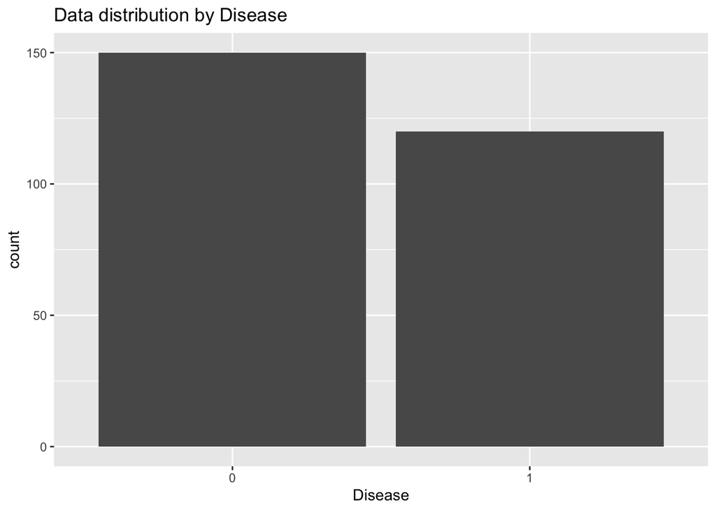

```r
# Count how many disease
ggplot(data=data, aes(as.factor(data$disease))) + geom_histogram(stat='count')+xlab("Disease")+ labs(title="Data distribution by Disease")
```

Then we look at the distribution of age for the entire dataset. The age ranges from 30 to almost 80.

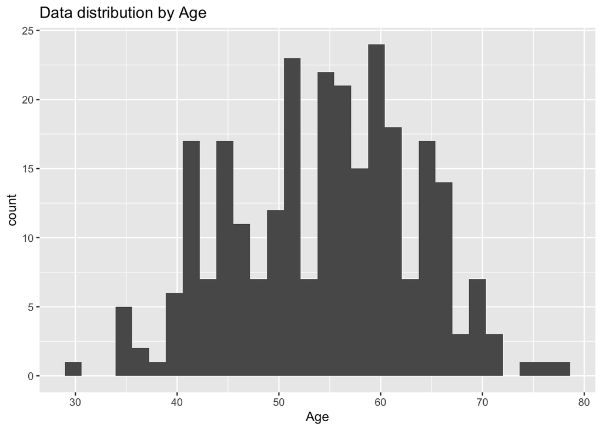

```r
#----------------The relationship between age and those who have heart diease----------------
# Look at the age, most of the people are around 40-60
ggplot(data=data, aes(data$age)) + geom_histogram()+xlab("Age")+ labs(title="Data distribution by Age")
```

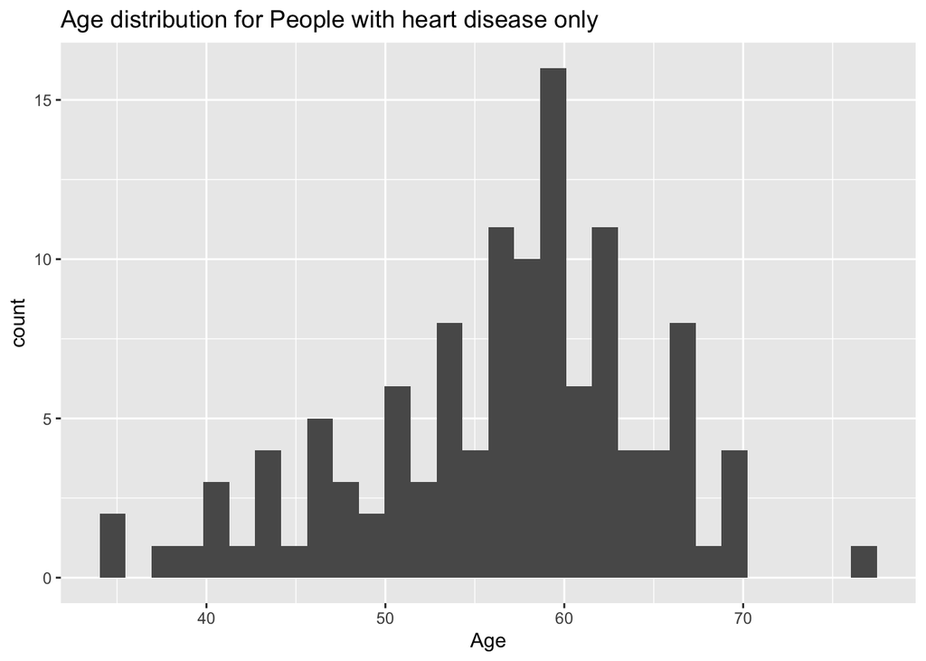

```r
# Look at those who have heart disease by age
ggplot(data=data[data$disease==1,], aes(data[data$disease==1,]$age)) + geom_histogram()+xlab("Age")+labs(title="Age distribution for People with heart disease only")
```

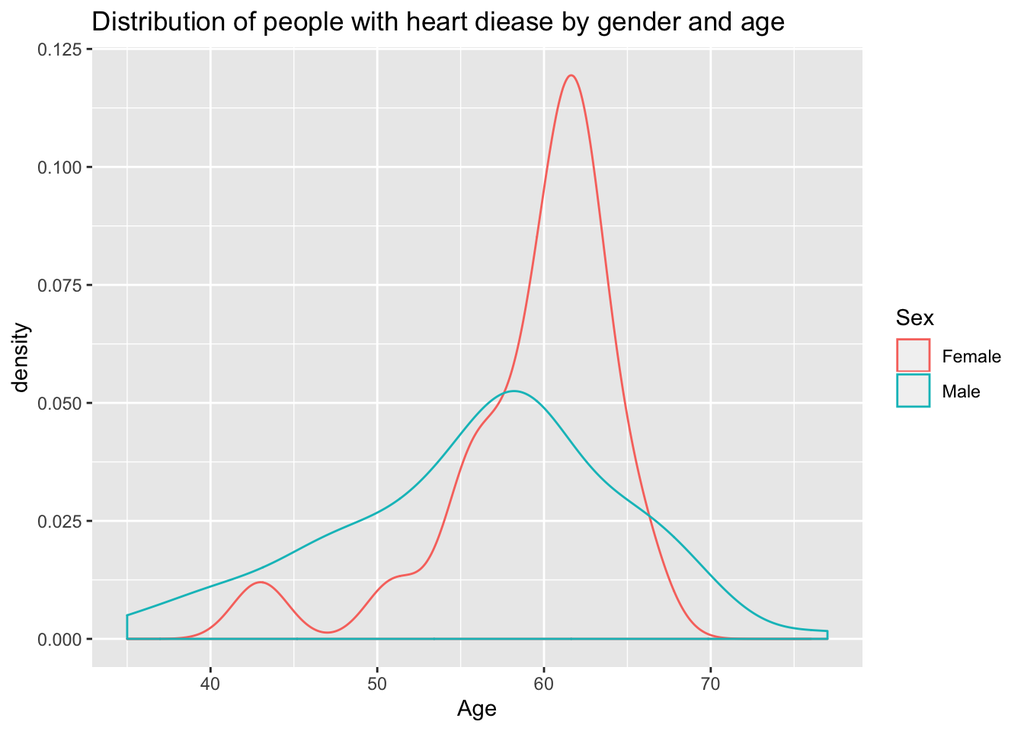

```r
# Use a density plot to see the relationship among age, sex in the people of heart diease
ggplot(data=data[data$disease==1,], aes(x=data[data$disease==1,]$age, colour=as.factor(data[data$disease==1,]$sex))) +
    geom_density()+xlab("Age")+labs(title="Distribution of people with heart diease by gender and age", colour='Sex')
```

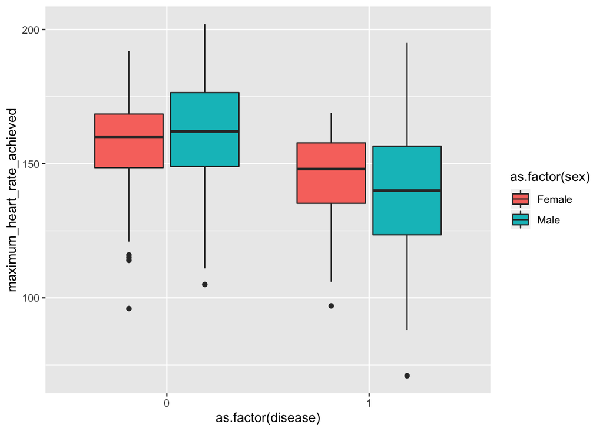

```r
# Compare characteristics between Absence (1) or presence (2) of heart disease
# Remember Absence (1) or presence (2) of heart disease
# Boxplot to comapre different distribution between heart disease and non heart disease
main <- ggplot(data = data)
main + geom_boxplot(mapping = aes(x = as.factor(disease), y = maximum_heart_rate_achieved, fill=as.factor(sex)))
```

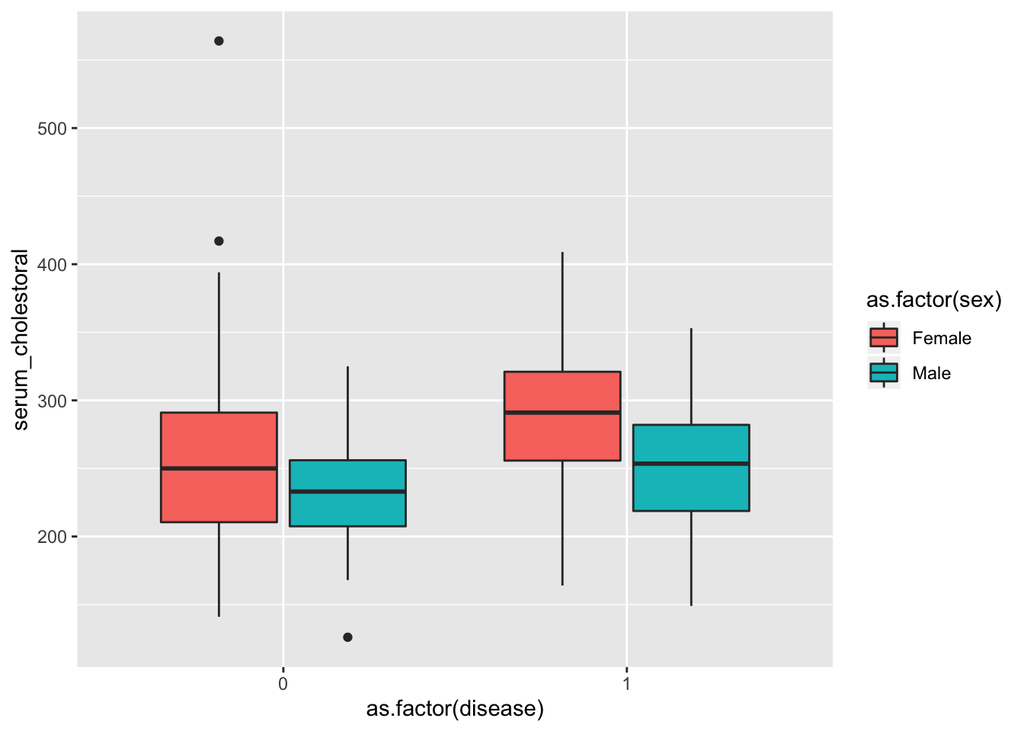

```r
main + geom_boxplot(mapping = aes(x = as.factor(disease), y = serum_cholestoral, fill=as.factor(sex)))
```

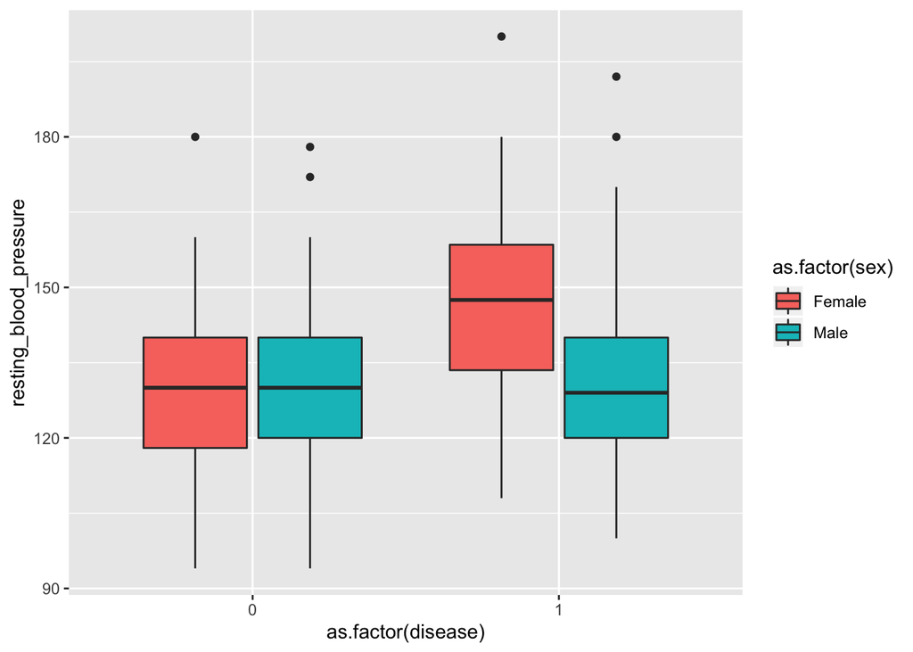

```r
main + geom_boxplot(mapping = aes(x = as.factor(disease), y = resting_blood_pressure, fill=as.factor(sex) ))
```

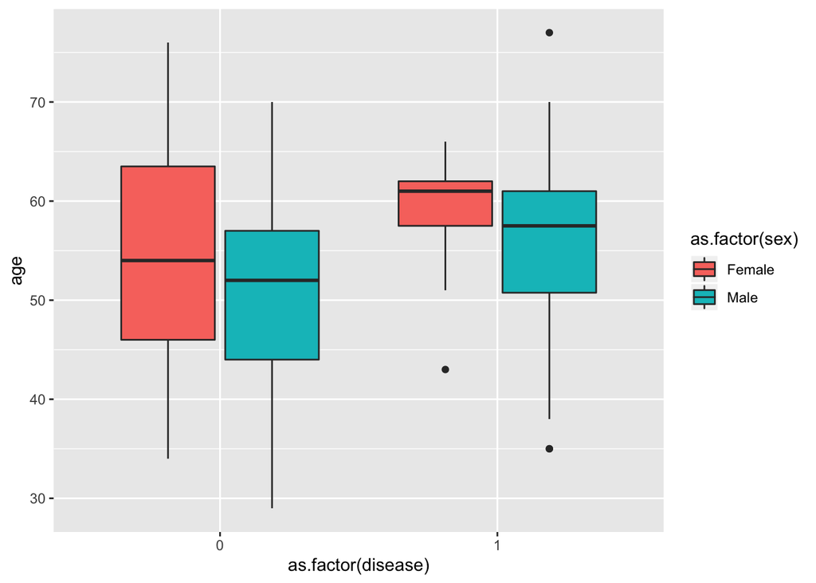

```r
main + geom_boxplot(mapping = aes(x = as.factor(disease), y = age, fill=as.factor(sex)))
```

Moreover, we want to explore the correlation among quantitative variables. We see that age and maximum heart rate achieved is negatively correlated. Other than that, we don’t see any strong correlation.

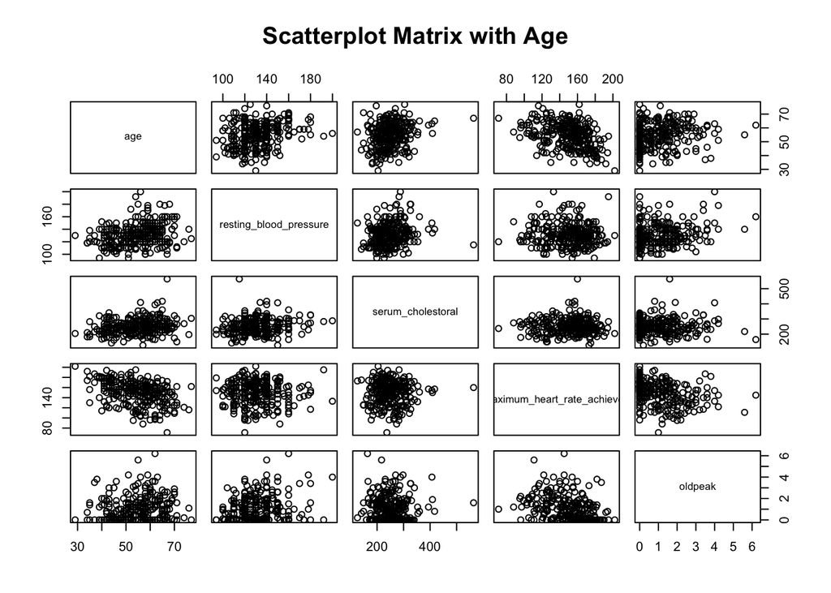

```r
# Scatterplot matrix: plotting all the real-valued variables
pairs(~age+resting_blood_pressure+serum_cholestoral+maximum_heart_rate_achieved+oldpeak,data=data, main="Scatterplot Matrix with Age")
```

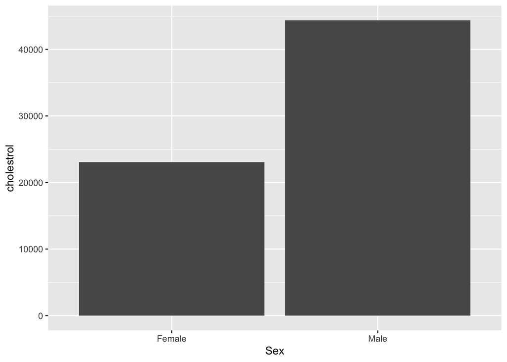

```r
# Male tends to have high cholestrol
g<-ggplot(data=data)
g+geom_bar(stat="identity",aes(x=as.factor(data$sex),y=data$serum_cholestoral))+xlab("Sex")+ylab("cholestrol")+theme(legend.position = "none")
```

```r
data$sex <- ifelse(data$sex=="Female",0,1)
```

```r
# Split training and testing data
set.seed(42)
# List = F means it should not return as a list, we split it in 80% 20%,
trainIndex <- sample(1: nrow(data), size=nrow(data)*0.8, replace=FALSE)
trainData <- data[trainIndex,]
testData <- data[-trainIndex,]
```

## Classification with logistic regression

For logistic regression model, we see that the predictor variable, age, doesn’t explain the response variable very well when other variables are present by looking at the p-value of 0.44687.

Also, the predictor, major vessels, explains the response variable more than the age since it is statistically significant with a p-value lower than 0.05.

Note that we use 0.6 cut-off threshold for the predicted probability for classification for model 1 by looking at the ROC curve.

```r
# Train a multiple logistic model
# Model 1: use all predictors with first order
model1 <- glm(disease~., data = trainData, family = "binomial")
summary(model1)
```

```
##
## Call:
## glm(formula = disease ~ ., family = "binomial", data = trainData)
##
## Deviance Residuals:
##      Min        1Q    Median        3Q       Max
## -2.90071  -0.40751  -0.06681   0.20977   2.58658
##
## Coefficients:
##                               Estimate Std. Error z value Pr(>|z|)
## (Intercept)                 -12.411896   4.620830  -2.686  0.00723 **
## age                          -0.024520   0.032235  -0.761  0.44687
## sex                           2.477725   0.770976   3.214  0.00131 **
## chest_pain_type2              1.592854   1.074428   1.483  0.13820
## chest_pain_type3              0.249334   0.827482   0.301  0.76317
## chest_pain_type4              3.084093   0.960968   3.209  0.00133 **
## resting_blood_pressure        0.041232   0.016031   2.572  0.01011 *
## serum_cholestoral             0.011039   0.005068   2.178  0.02940 *
## fasting_blood_sugar          -0.204411   0.777162  -0.263  0.79253
## resting_results1              1.067955   6.500698   0.164  0.86951
## resting_results2              0.707289   0.511480   1.383  0.16672
## maximum_heart_rate_achieved  -0.014832   0.014398  -1.030  0.30297
## exercise_induced_angina       0.886498   0.590628   1.501  0.13337
## oldpeak                       0.641531   0.325382   1.972  0.04865 *
## slope                         0.817491   0.526348   1.553  0.12039
## major_vessels                 1.743948   0.383160   4.551 5.33e-06 ***
## thal6                        -1.112763   1.027720  -1.083  0.27892
## thal7                         1.593891   0.576981   2.762  0.00574 **
## ---
## Signif. codes:  0 '***' 0.001 '**' 0.01 '*' 0.05 '.' 0.1 ' ' 1
##
## (Dispersion parameter for binomial family taken to be 1)
##
##     Null deviance: 297.59  on 215  degrees of freedom
## Residual deviance: 113.84  on 198  degrees of freedom
## AIC: 149.84
##
## Number of Fisher Scoring iterations: 7
```

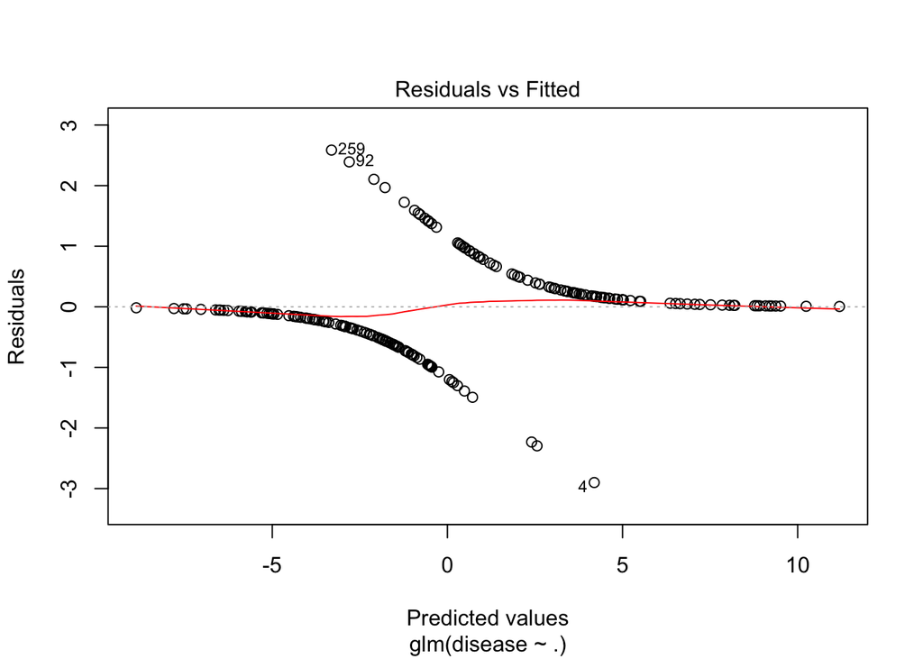

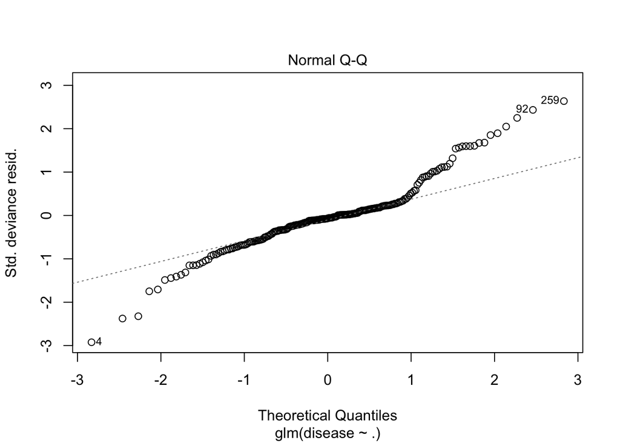

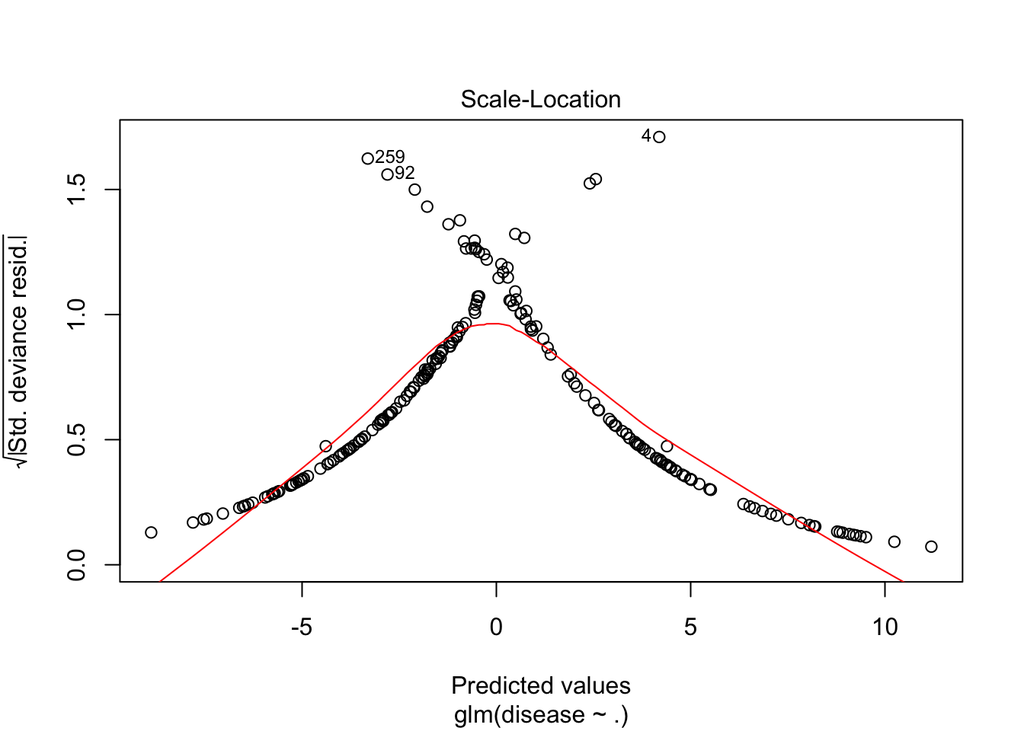

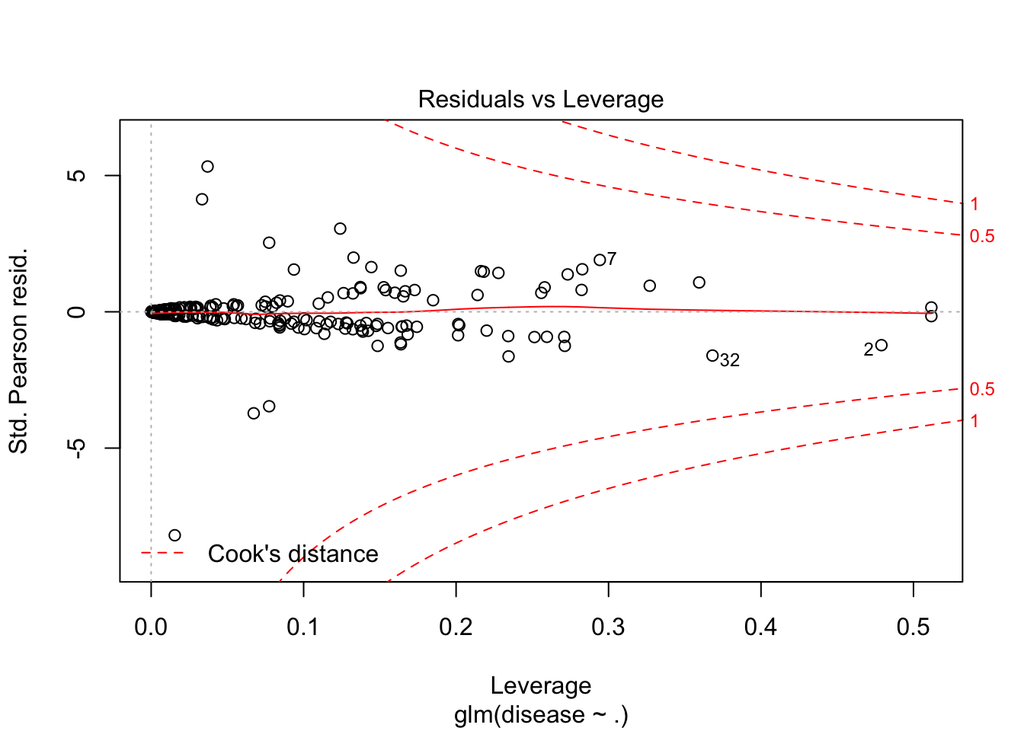

```r
plot(model1)
```

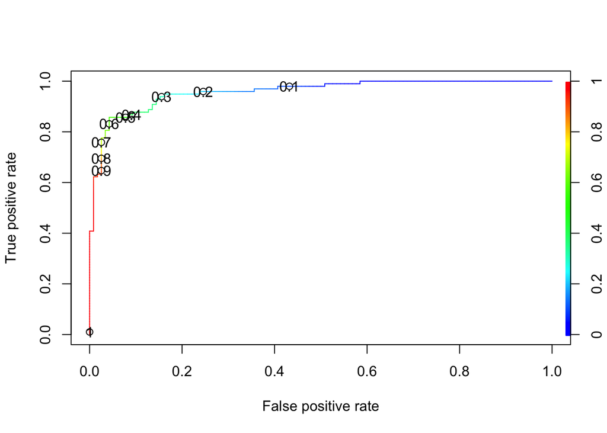

```r
# choosing the best cut-off probabillity value to the model
res <- predict(model1,type ="response")
ROCR_pred <- prediction(res,trainData$disease)
ROCR_perf <- performance(ROCR_pred,"tpr","fpr")
plot(ROCR_perf,colorize=T,print.cutoffs.at =seq(0.1,by =0.1))
```

```r
predicted <- ifelse(predict(model1, testData, type='response')>.6,1,0)

confusion<-table(predicted,factor(testData$disease),dnn = c("Predicted presense","True presense"))


# Use recall rate to see how many actual people with heart-dieases we are able to capture
confusion[4]/(confusion[3]+confusion[4])
```

```
## [1] 0.7272727
```

```r
# Sensitivity
sum(diag(confusion))/sum(confusion)
```

```
## [1] 0.7777778
```

```r
# Model 2: Will dropping potential outliers improve performance?
data_drop_out <- trainData[!(rownames(trainData) %in% c("259","4")),]

model2 <- glm(disease~., data = data_drop_out, family = "binomial")
summary(model2)
```

```
##
## Call:
## glm(formula = disease ~ ., family = "binomial", data = data_drop_out)
##
## Deviance Residuals:
##      Min        1Q    Median        3Q       Max
## -2.67276  -0.32067  -0.03506   0.11504   2.68023
##
## Coefficients:
##                               Estimate Std. Error z value Pr(>|z|)
## (Intercept)                 -12.979250   5.205289  -2.493 0.012650 *
## age                          -0.037293   0.036197  -1.030 0.302878
## sex                           2.731580   0.889653   3.070 0.002138 **
## chest_pain_type2              2.328460   1.222938   1.904 0.056912 .
## chest_pain_type3              0.057444   0.884611   0.065 0.948224
## chest_pain_type4              3.808252   1.140201   3.340 0.000838 ***
## resting_blood_pressure        0.047078   0.017846   2.638 0.008339 **
## serum_cholestoral             0.011307   0.005641   2.004 0.045045 *
## fasting_blood_sugar           0.022744   0.857091   0.027 0.978830
## resting_results1              1.183324  10.220345   0.116 0.907826
## resting_results2              0.889281   0.575940   1.544 0.122576
## maximum_heart_rate_achieved  -0.024034   0.016655  -1.443 0.148994
## exercise_induced_angina       1.078541   0.655789   1.645 0.100042
## oldpeak                       0.740198   0.369311   2.004 0.045042 *
## slope                         1.203081   0.583679   2.061 0.039284 *
## major_vessels                 2.150148   0.459958   4.675 2.94e-06 ***
## thal6                        -1.373628   1.102954  -1.245 0.212982
## thal7                         2.215733   0.681790   3.250 0.001155 **
## ---
## Signif. codes:  0 '***' 0.001 '**' 0.01 '*' 0.05 '.' 0.1 ' ' 1
##
## (Dispersion parameter for binomial family taken to be 1)
##
##     Null deviance: 294.795  on 213  degrees of freedom
## Residual deviance:  96.174  on 196  degrees of freedom
## AIC: 132.17
##
## Number of Fisher Scoring iterations: 7
```

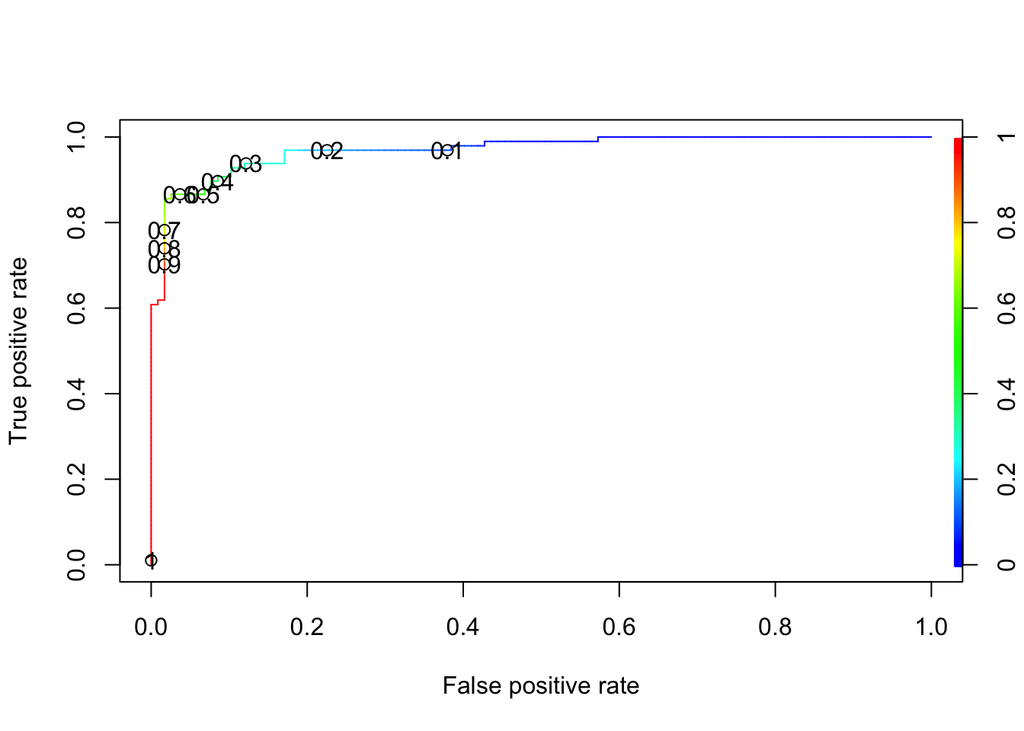

```r
# choosing the best cut-off probabillity value to the model
res <- predict(model2,type ="response")
ROCR_pred <- prediction(res,data_drop_out$disease)
ROCR_perf <- performance(ROCR_pred,"tpr","fpr")
plot(ROCR_perf,colorize=T,print.cutoffs.at =seq(0.1,by =0.1))
```

```r
predicted <- ifelse(predict(model2, testData, type='response')>.5,1,0)

confusion_drop<-table(predicted,factor(testData$disease),dnn = c("Predicted presense","True presense"))

# Use recall rate to see how many actual people with heart-dieases we are able to capture
confusion_drop[4]/(confusion_drop[3]+confusion_drop[4])
```

```
## [1] 0.7727273
```

```r
# Sensitivity
sum(diag(confusion_drop))/sum(confusion_drop)
```

```
## [1] 0.7777778
```

Also, model 3 that utilizes two-way interaction terms does not necessarily perform better than model 2 which only include first order predictors. Therefore, combining predictors into one predictor variable may not necessarily improve classification performance.

```r
# Model 3: use all predictors with 2-way interaction term to see if we can gain any accuracy gain
model3 <- glm(disease~.^2, data = data_drop_out, family = "binomial")
summary(model3)
```

```
##
## Call:
## glm(formula = disease ~ .^2, family = "binomial", data = data_drop_out)
##
## Deviance Residuals:
##        Min          1Q      Median          3Q         Max
## -1.425e-05  -2.409e-06  -2.110e-08   2.014e-06   1.295e-05
##
## Coefficients: (17 not defined because of singularities)
##                                                       Estimate Std. Error
## (Intercept)                                         -5.570e+02  7.672e+07
## age                                                 -5.377e+00  3.149e+05
## sex                                                  6.421e+02  1.314e+07
## chest_pain_type2                                     1.204e+02  8.384e+07
## chest_pain_type3                                     4.911e+02  8.373e+07
## chest_pain_type4                                     1.832e+02  9.136e+07
## resting_blood_pressure                              -3.374e+00  6.905e+05
## serum_cholestoral                                    2.194e+00  1.876e+05
## fasting_blood_sugar                                 -4.970e+02  1.366e+07
## resting_results1                                    -8.168e+02  1.198e+07
## resting_results2                                     1.519e+02  4.759e+06
## maximum_heart_rate_achieved                          3.687e+00  1.461e+05
## exercise_induced_angina                             -6.460e+01  1.110e+07
## oldpeak                                              4.809e+00  1.720e+07
## slope                                               -3.248e+01  1.464e+07
## major_vessels                                        4.525e+00  9.135e+06
## thal6                                               -6.702e+02  6.426e+07
## thal7                                               -2.908e+02  1.524e+07
## age:sex                                             -1.704e+00  3.741e+04
## age:chest_pain_type2                                 9.135e-01  2.828e+05
## age:chest_pain_type3                                -7.103e-02  1.597e+05
## age:chest_pain_type4                                 1.984e+00  3.990e+05
## age:resting_blood_pressure                          -1.911e-04  1.270e+03
## age:serum_cholestoral                               -5.421e-03  4.611e+02
## age:fasting_blood_sugar                              2.585e+00  1.051e+05
## age:resting_results1                                 1.151e+01  1.677e+05
## age:resting_results2                                 1.451e+00  6.333e+04
## age:maximum_heart_rate_achieved                      3.494e-02  1.012e+03
## age:exercise_induced_angina                         -2.457e+00  9.355e+04
## age:oldpeak                                          1.126e+00  9.718e+04
```

[output cut: 262 more lines]

```
## oldpeak:thal6                                             0        1
## oldpeak:thal7                                             0        1
## slope:major_vessels                                       0        1
## slope:thal6                                              NA       NA
## slope:thal7                                               0        1
## major_vessels:thal6                                      NA       NA
## major_vessels:thal7                                       0        1
##
## (Dispersion parameter for binomial family taken to be 1)
##
##     Null deviance: 2.9480e+02  on 213  degrees of freedom
## Residual deviance: 4.6167e-09  on  82  degrees of freedom
## AIC: 264
##
## Number of Fisher Scoring iterations: 25
```

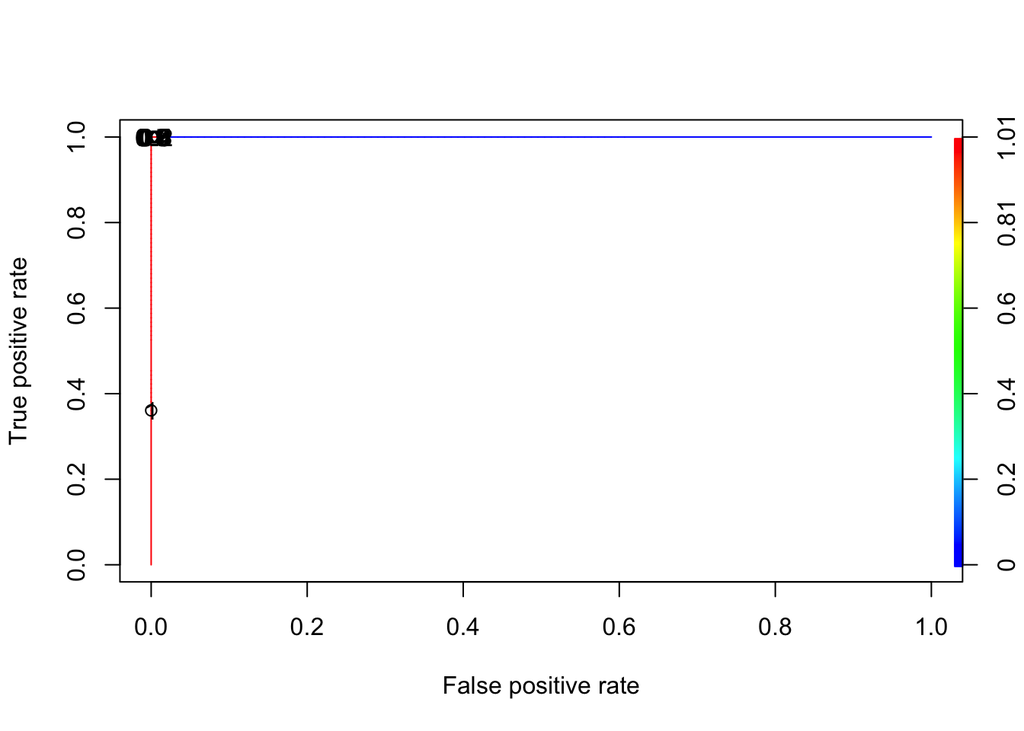

```r
# choosing the best cut-off probabillity value to the model
res3 <- predict(model3,type ="response")
ROCR_pred3 <- prediction(res3,data_drop_out$disease)
ROCR_perf3 <- performance(ROCR_pred3,"tpr","fpr")
plot(ROCR_perf3,colorize=T,print.cutoffs.at =seq(0.1,by =0.1))
```

```r
predicted3 <- ifelse(predict(model3, testData, type='response')>.6,1,0)
confusion3<-table(predicted3,factor(testData$disease),dnn = c("Predicted presense","True presense"))

# Use recall rate to see how many actual people with heart-dieases we are able to capture
confusion3[4]/(confusion3[3]+confusion3[4])
```

```
## [1] 0.7727273
```

```r
# Sensitivity
sum(diag(confusion3))/sum(confusion3)
```

```
## [1] 0.7222222
```

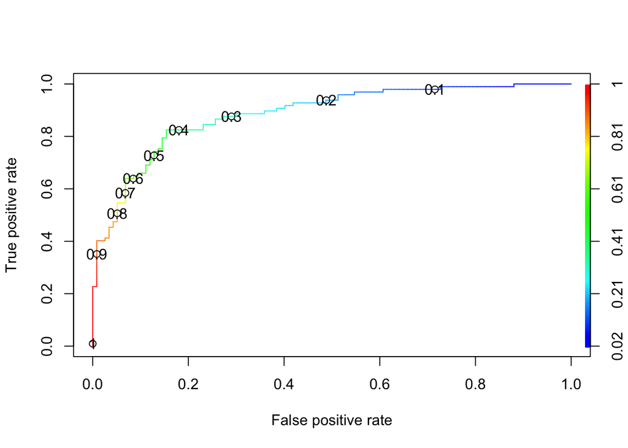

```r
# Model4: use only real valued variables
model4 <- glm(disease~age+resting_blood_pressure+serum_cholestoral+maximum_heart_rate_achieved+oldpeak+major_vessels, data = data_drop_out, family = "binomial")

# choosing the best cut-off probabillity value to the model
res4 <- predict(model4,type ="response")
ROCR_pred4 <- prediction(res4,data_drop_out$disease)
ROCR_perf4 <- performance(ROCR_pred4,"tpr","fpr")
plot(ROCR_perf4,colorize=T,print.cutoffs.at =seq(0.1,by =0.1))
```

```r
predicted4 <- ifelse(predict(model4, testData, type='response')>.6,1,0)
confusion4<-table(predicted4,factor(testData$disease),dnn = c("Predicted presense","True presense"))

# Use recall rate to see how many actual people with heart-dieases we are able to capture
confusion4[4]/(confusion4[3]+confusion4[4])
```

```
## [1] 0.5909091
```

```r
# Sensitivity
sum(diag(confusion4))/sum(confusion4)
```

```
## [1] 0.7592593
```

```r
# Let's try something new by using cross validation
fitcontrol <- trainControl(method="repeatedcv", number=10, repeats=3)
# train the model
model_importance <- train(factor(disease)~., data=data_drop_out, method="glm", trControl=fitcontrol, family = "binomial")
# estimate variable importance
importance <- varImp(model_importance , scale=FALSE)
# summarize importance
print(importance)
```

```
## glm variable importance
##
##                             Overall
## major_vessels               4.67467
## chest_pain_type4            3.33998
## thal7                       3.24987
## sex                         3.07039
## resting_blood_pressure      2.63801
## slope                       2.06120
## oldpeak                     2.00427
## serum_cholestoral           2.00424
## chest_pain_type2            1.90399
## exercise_induced_angina     1.64465
## resting_results2            1.54405
## maximum_heart_rate_achieved 1.44309
## thal6                       1.24541
## age                         1.03028
## resting_results1            0.11578
## chest_pain_type3            0.06494
## fasting_blood_sugar         0.02654
```

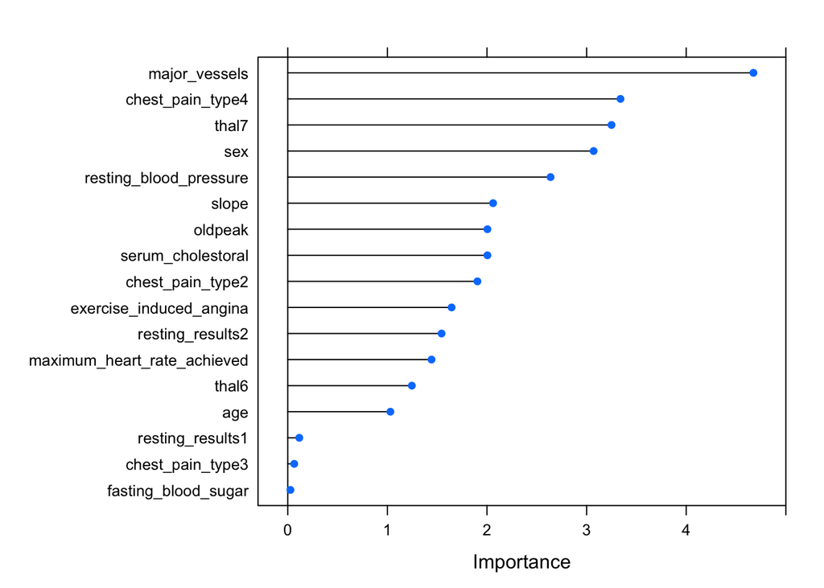

```r
# plot importance
plot(importance)
```

Note that the model 5 doesn’t use all the predictor variables provided in the dataset, but it can still outperform the model that uses all predictors. We are able to avoid using fasting blood sugar to predict the presence of heart disease. Therefore, it is possible to utilize only some of the predictors to achieve satisfactory performance

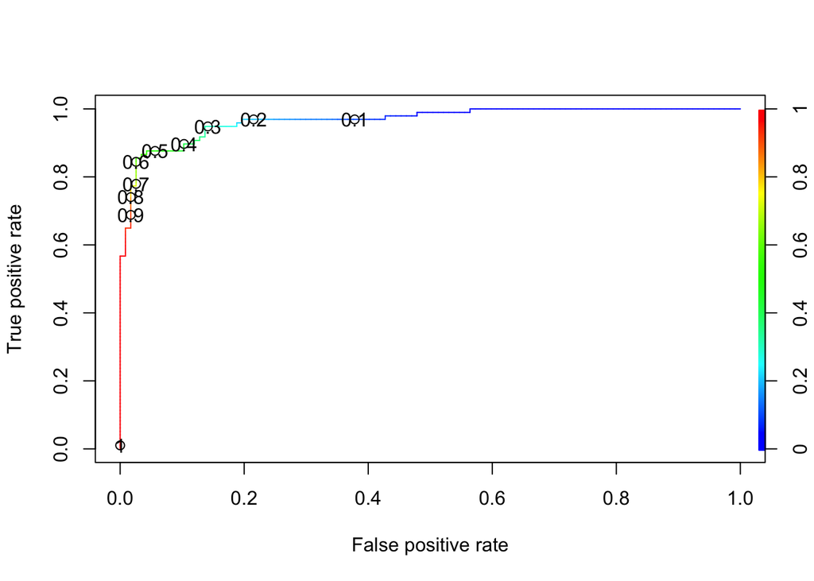

```r
# Model 5: using the top 8 most important features
model5 <- glm(disease~major_vessels+chest_pain_type+thal+sex+resting_blood_pressure+slope+oldpeak+serum_cholestoral+exercise_induced_angina+maximum_heart_rate_achieved, data = data_drop_out, family = "binomial")

# Plot ROC curve
res5 <- predict(model5,type ="response")
ROCR_pred5 <- prediction(res5,data_drop_out$disease)
ROCR_perf5 <- performance(ROCR_pred5,"tpr","fpr")
plot(ROCR_perf5,colorize=T,print.cutoffs.at =seq(0.1,by =0.1))
```

```r
predicted5 <- ifelse(predict(model5, testData, type='response')>.6,1,0)
confusion5<-table(predicted5,factor(testData$disease),dnn = c("Predicted presense","True presense"))

# Calculate the number of actual number of people with heart-dieases that we are able to capture
confusion5[4]/(confusion5[3]+confusion5[4])
```

```
## [1] 0.7727273
```

```r
# Sensitivity
sum(diag(confusion5))/sum(confusion5)
```

```
## [1] 0.7962963
```